# Statistical Inference Project 2

JD

Saturday, May 23, 2015

#### Overview

The objective To analyze the ToothGrowth data in the R datasets package ToothGrowth. This has observations for 60 samples (Animals). These animals were divided into 6 groups of 10 and consistently fed a diet with one of 6 Vitamin C supplement regimes for a period of 42 days. The Vitamin C was administered either in the form of Orange Juice (OJ) or chemically pure Vitamin C in aqueous solution (VC). Each animal received the same daily dosage of Vitamin C (either 0.5, 1.0 or 2.0 milligrams) consistently.

#### 1. Load the ToothGrowth data

```r
library(ggplot2)
library(datasets)
data(ToothGrowth)

## This function returns the title for facet grids (Ref http://www.cookbook-r.com/Graphs/Facets_(ggplot2)/)
mf_labeller <- function(var, value){
  value <- as.character(value)
  if (var=="supp") {
    value[value=="OJ"] <- "Orange Juice"
    value[value=="VC"]   <- "Vit C Aqeuous Soln"
  }
  return(value)
}
```

**Displaying Tooth Growth Datasets basics**

#### 2. Summary and Structure

**A. Summary**

```r
summary(ToothGrowth)
```

```
##       len        supp         dose
##  Min.   : 4.20   OJ:30   Min.   :0.500
##  1st Qu.:13.07   VC:30   1st Qu.:0.500
##  Median :19.25           Median :1.000
##  Mean   :18.81           Mean   :1.167
##  3rd Qu.:25.27           3rd Qu.:2.000
##  Max.   :33.90           Max.   :2.000
```

**B. Basic Structure**

```r
str(ToothGrowth)
```

```
## 'data.frame':    60 obs. of  3 variables:
##  $ len : num  4.2 11.5 7.3 5.8 6.4 10 11.2 11.2 5.2 7 ...
##  $ supp: Factor w/ 2 levels "OJ","VC": 2 2 2 2 2 2 2 2 2 2 ...
##  $ dose: num  0.5 0.5 0.5 0.5 0.5 0.5 0.5 0.5 0.5 0.5 ...
```

#### 3. Displaying Tooth Growth Plot and basic analysis

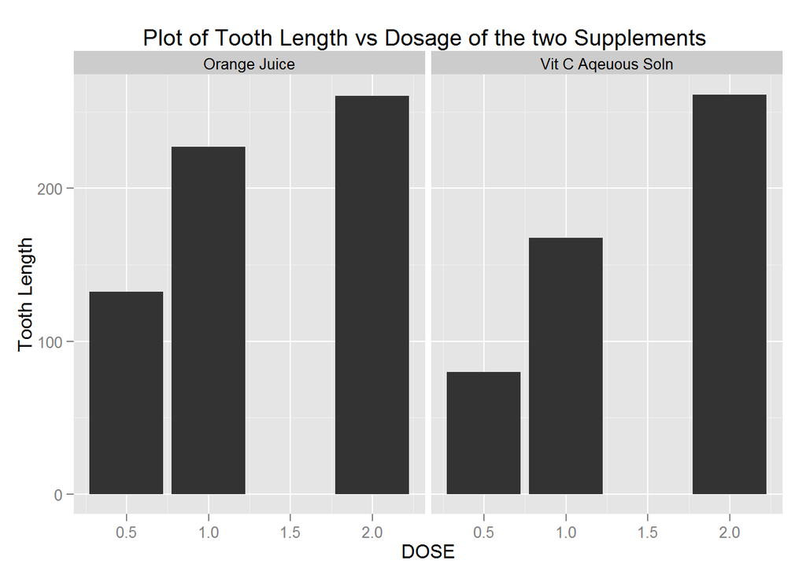

```r
ggplot(data=ToothGrowth, aes(dose, len)) +geom_bar(stat="identity") + facet_grid(.~supp, drop=FALSE,labeller=mf_labeller) + xlab("DOSE") + ylab("Tooth Length")+
  ggtitle("Plot of Tooth Length vs Dosage of the two Supplements ")
```

#### 5. Detailed Analysis

**Here we attain p values to evaluate null hypothesis.**

**A. Load Datasets for dosage levels**

```r
## Load data sets for the three dosage levels
dosage01 <- subset(ToothGrowth, dose==0.5)
dosage02 <- subset(ToothGrowth, dose==1.0)
dosage03 <- subset(ToothGrowth, dose==2.0)
```

**B. Perform T Test on the three sets of data. P Values printed below**

```r
t<-t.test(len~supp, paired=FALSE, data=dosage01)
t$p.value
```

```
## [1] 0.006358607
```

```r
t<-t.test(len~supp, paired=FALSE, data=dosage02)
t$p.value
```

```
## [1] 0.001038376
```

```r
t<-t.test(len~supp, paired=FALSE, data=dosage03)
t$p.value
```

```
## [1] 0.9638516
```

#### 6. Analysis & Assumptions

*Dosage of 0.5 and 1.0 have p values of 0.0063 and 0.0010 respectively. Dosage of 2.0 has p value of 0.9638.* *Orange Juice and Vit C has greater impact on tooth growth at lower levels. At higher dosages the differences the two supplements have no differences to tooth growth.*

#### 7. References

[Refer This Link for details on P Value ( http://www.dummies.com/how-to/content/what-a-pvalue-tells-you-about-statistical-data.html)